# Feature Scaling

### Feature Scaling

With any distance based machine learning model (regularized regression methods, neural networks, and now kmeans), you will want to scale your data.

If you have some features that are on completely different scales, this can greatly impact the clusters you get when using K-Means.

```python
import numpy as np
import pandas as pd
from sklearn.cluster import KMeans
import matplotlib.pyplot as plt
from sklearn import preprocessing as p

%matplotlib inline

plt.rcParams['figure.figsize'] = (16, 9)
import helpers2 as h
import tests as t


# Create the dataset for the notebook
data = h.simulate_data(200, 2, 4)
df = pd.DataFrame(data)
df.columns = ['height', 'weight']
df['height'] = np.abs(df['height']*100)
df['weight'] = df['weight'] + np.random.normal(50, 10, 200)
```

`1.` take a look at the data to get familiar with it.

```python
#Take a look at the data
df.describe()
```

|  | height | weight |
| --- | --- | --- |
| count | 200.000000 | 200.000000 |
| mean | 569.726207 | 54.376879 |
| std | 246.966215 | 11.632868 |
| min | 92.998481 | 22.899057 |
| 25% | 357.542793 | 46.686159 |
| 50% | 545.766752 | 53.269889 |
| 75% | 773.310607 | 61.455956 |
| max | 1096.222348 | 84.017206 |

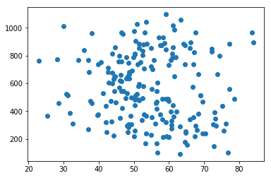

```python
#use this cell if you would like as well
plt.scatter(df['weight'], df['height'])
```

There are two very common types of feature scaling :

**I. MinMaxScaler**

In some cases it is useful to think of your data in terms of the percent they are as compared to the maximum value. In these cases, you will want to use **MinMaxScaler**.

**II. StandardScaler**

Another very popular type of scaling is to scale data so that it has mean 0 and variance 1. In these cases, you will want to use **StandardScaler**.

It is probably more appropriate with this data to use **StandardScaler**. However, to get practice with feature scaling methods in python, we will perform both.

`2.` First fit the **StandardScaler** transformation to this dataset.

```python
df_ss = p.StandardScaler().fit_transform(df) # Fit and transform the data
df_ss
```

[output not shown]

[output cut: 145 more lines]

[output not shown]

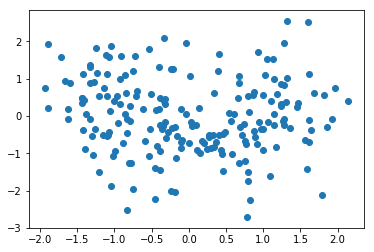

```python
df_ss = pd.DataFrame(df_ss) #create a dataframe
df_ss.columns = ['height', 'weight'] #add column names again

plt.scatter(df_ss['height'], df_ss['weight']); # create a plot
```

`3.` fitting the **MinMaxScaler** transformation to this dataset.

```python
# fit and transform
df_mm= p.MinMaxScaler().fit_transform(df)
```

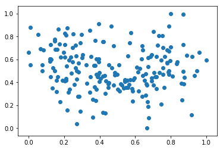

```python
#create a dataframe
df_mm = pd.DataFrame(df_mm)
#change the column names
df_mm.columns = ['height', 'weight']

#plot the data
plt.scatter(df_mm['height'], df_mm['weight'])
```

`4.` take a look at how kmeans divides the dataset into different groups for each of the different scalings of the data.

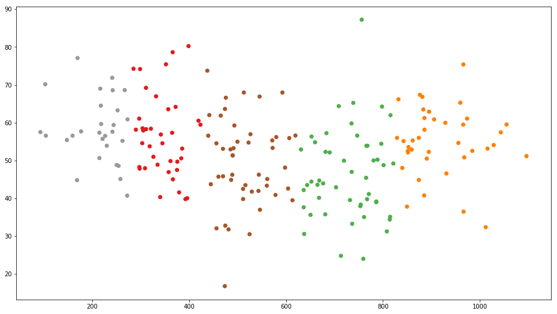

```python
def fit_kmeans(data, centers):
    '''
    INPUT:
        data = the dataset you would like to fit kmeans to (dataframe)
        centers = the number of centroids (int)
    OUTPUT:
        labels - the labels for each datapoint to which group it belongs (nparray)

    '''
    kmeans = KMeans(centers)
    labels = kmeans.fit_predict(data)
    return labels

labels = fit_kmeans(df, 5) #fit kmeans to get the labels
# Plot the original data with clusters
plt.scatter(df['height'], df['weight'], c=labels, cmap='Set1');
```

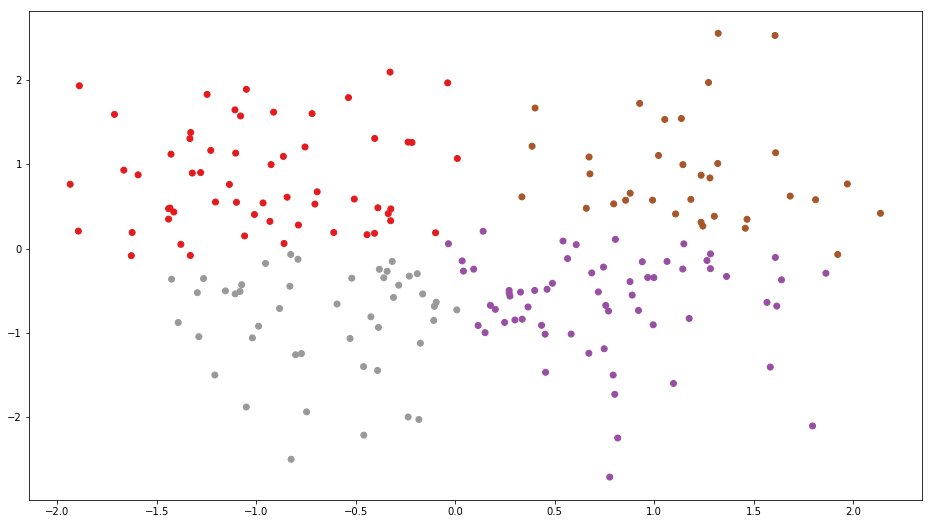

```python
#plot each of the scaled datasets
labels = fit_kmeans(df_ss, 4) #fit kmeans to get the labels

plt.scatter(df_ss['height'], df_ss['weight'], c=labels, cmap='Set1');
```

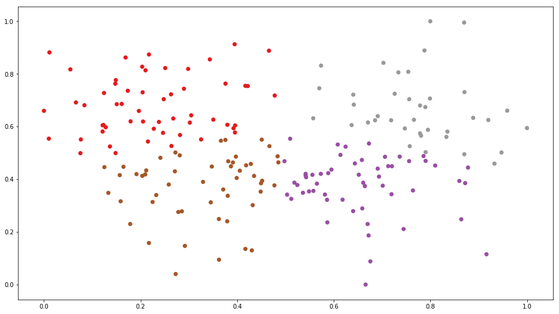

```python
#another plot of the other scaled dataset
labels = fit_kmeans(df_mm, 4) #fit kmeans to get the labels

plt.scatter(df_mm['height'], df_mm['weight'], c=labels, cmap='Set1');
```

with scaling the two features the clustering changed, and the two scaling approaches generate the same clustering

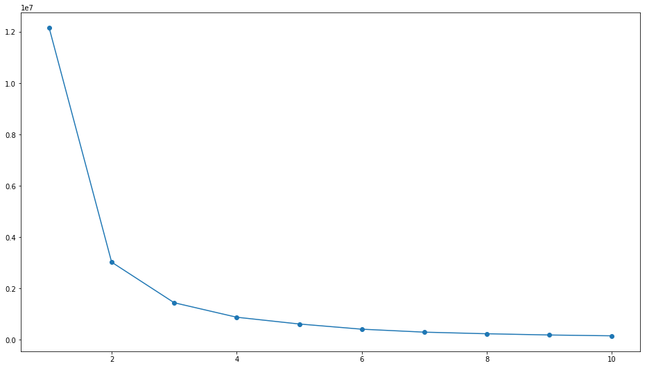

```python
#see the elbow point.. so it can affect on the similarity between the clusters into two scaling approaches
def plot_scores(data,centroid):
    kmeans = KMeans(centroid)
    model = kmeans.fit(data)
    score = np.abs(model.score(data))
    return score

centroids = [i for i in range(1,11)]
scores = []

for i in centroids:
    scores.append(plot_scores(df,i))

plt.plot(centroids, scores, marker = 'o');
```